# Healthylife insurance charge prediction - Project 2

# Online/Batch Inferencing

### Paste your gradio app link

Note: Make sure your Hugging Face space repository is set to public. If it's private, the evaluator won't be able to access the app you've built, which could result in losing marks.

```python
# Install the gradio_client package silently
!pip install -q gradio_client
```

```python
import time  # Import the time module for time-related functions
from gradio_client import Client  # Import the Gradio client for interacting with Gradio interfaces
from sklearn.datasets import fetch_openml  # Import fetch_openml to fetch datasets
from sklearn.model_selection import train_test_split  # Import train_test_split for splitting datasets
from tqdm import tqdm  # Import tqdm for progress bars
```

## Test Data

```python
import pandas as pd  # Import pandas for data manipulation
from sklearn.model_selection import train_test_split  # Import train_test_split for splitting datasets

# Read the dataset from the CSV file into a DataFrame
data_df = pd.read_csv("insurance.csv")

# Define the target variable
target = 'charges'

# Define the numeric features used for modeling
numeric_features = ['age', 'bmi', 'children']

# Define the categorical features used for modeling
categorical_features = ['sex', 'smoker','region']

# Separate features (X) and target variable (y)
X = data_df.drop('charges', axis=1)
y = data_df['charges']

# Display a message indicating the creation of data subsets
print("data subsets are being created")

# Split the dataset into training and testing sets
Xtrain, Xtest, ytrain, ytest = train_test_split(
    X, y,
    test_size=0.2,
    random_state=42
)
```

```
data subsets are being created
```

```python
# Check the shape of the testing features dataset
Xtest.shape
```

```
(268, 7)
```

```python
# Display the first 3 rows of the testing features dataset
Xtest.head(3)
```

|  | index | age | sex | bmi | children | smoker | region |
| --- | --- | --- | --- | --- | --- | --- | --- |
| 764 | 764 | 45 | female | 25.175 | 2 | no | northeast |
| 887 | 887 | 36 | female | 30.020 | 0 | no | northwest |
| 890 | 890 | 64 | female | 26.885 | 0 | yes | northwest |

#### Distributions

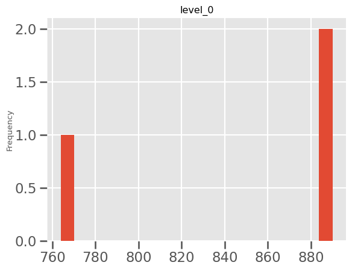

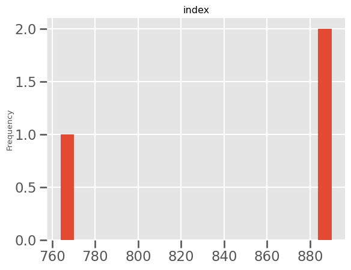

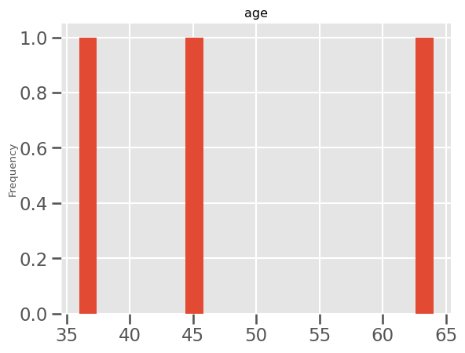

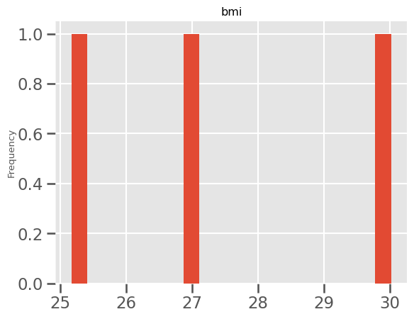

#### Categorical distributions

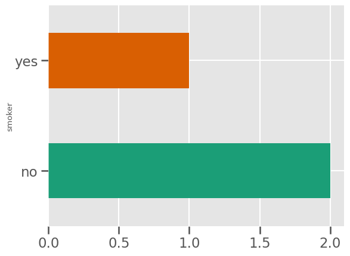

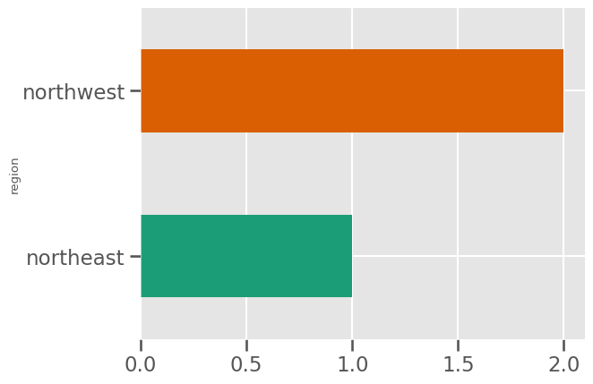

#### 2-d distributions

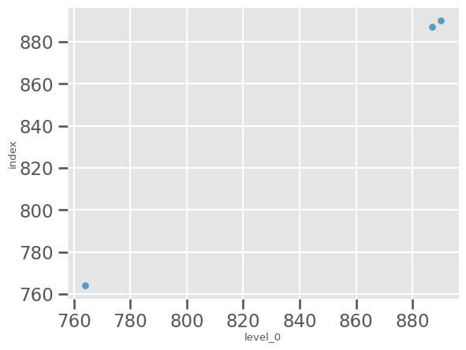

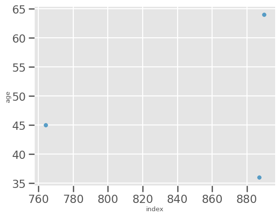

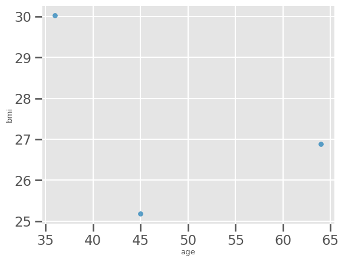

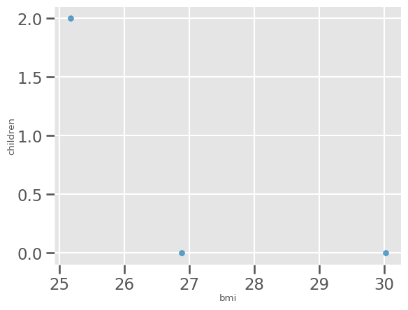

#### Time series

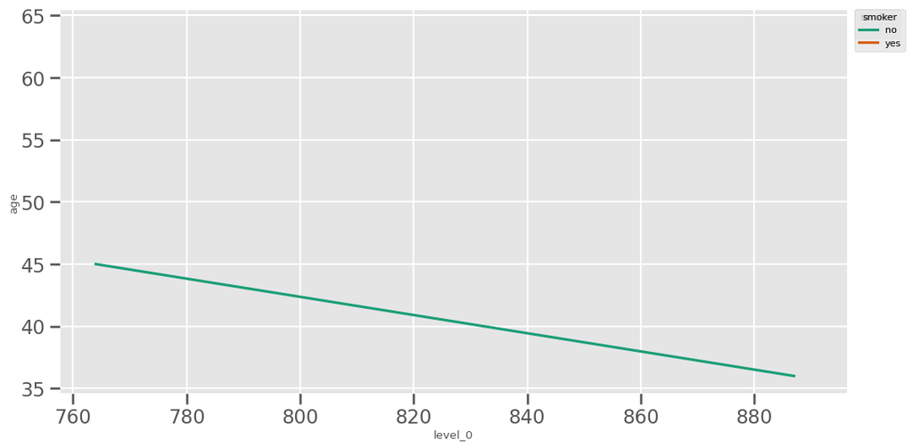

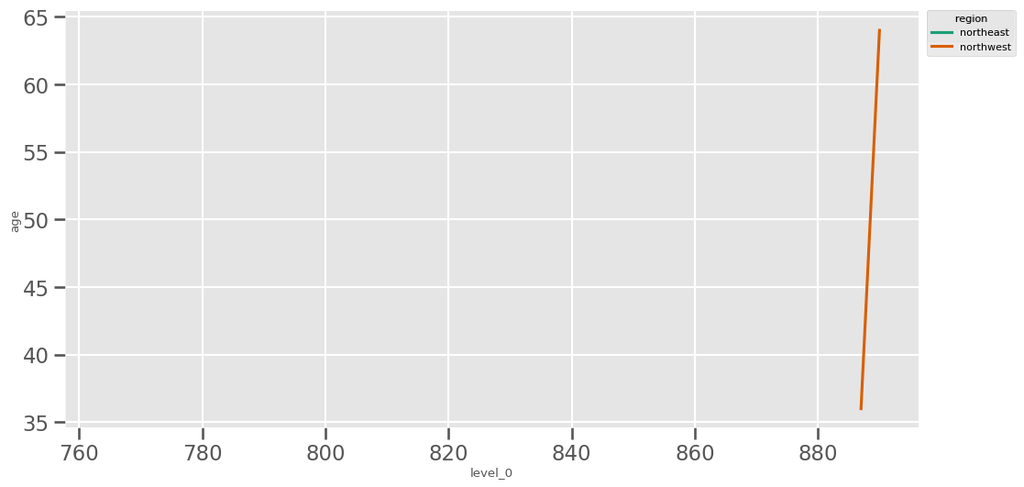

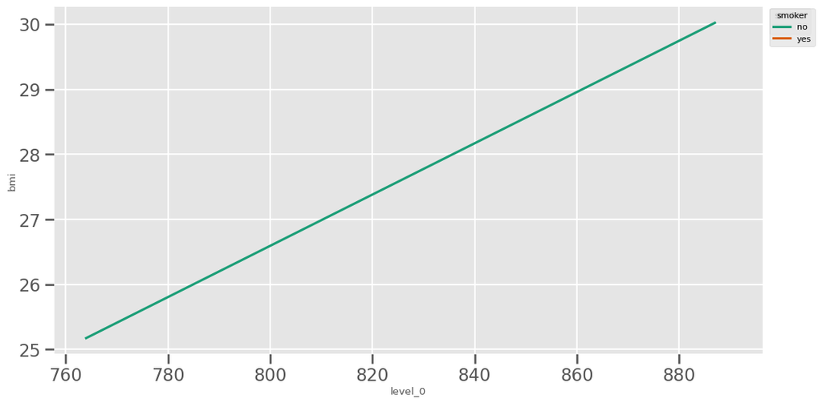

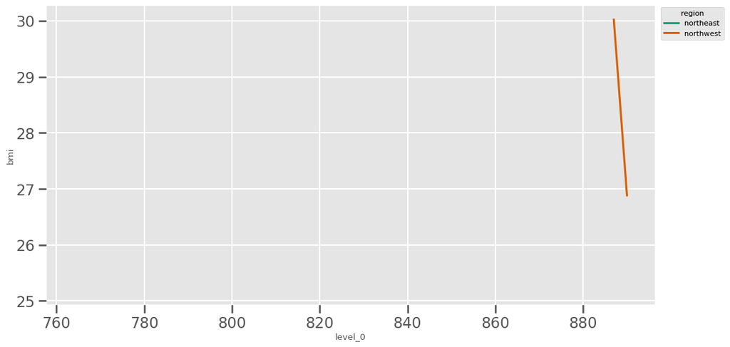

#### Values

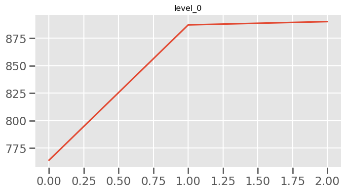

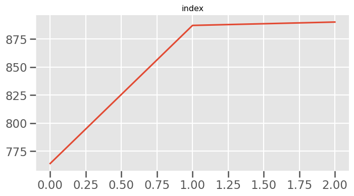

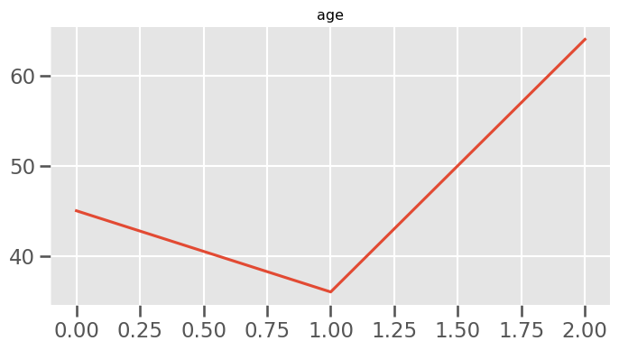

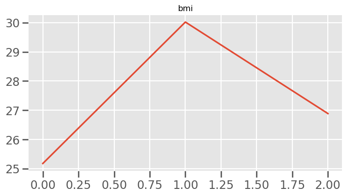

#### 2-d categorical distributions

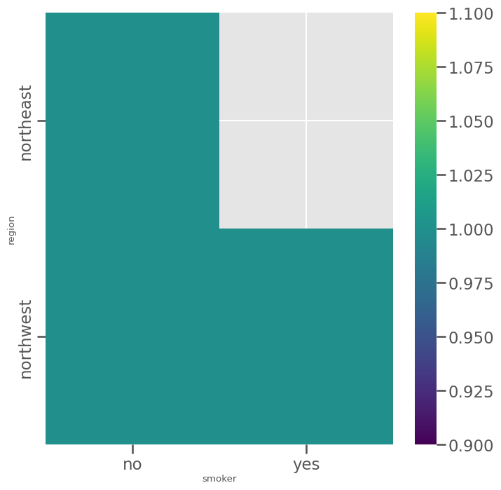

#### Faceted distributions

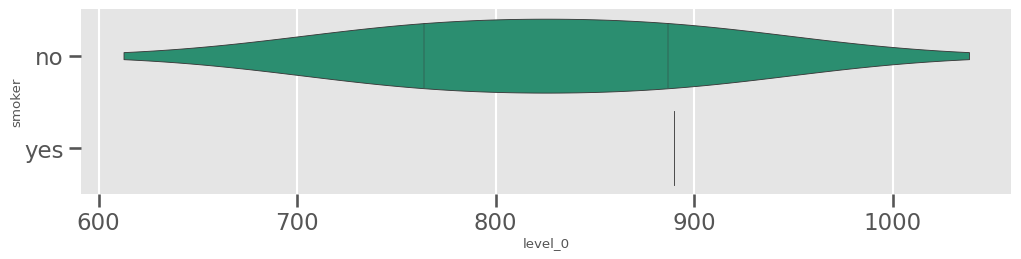

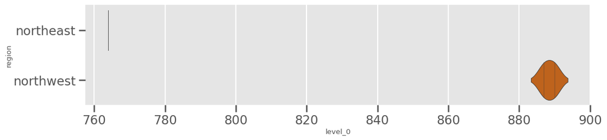

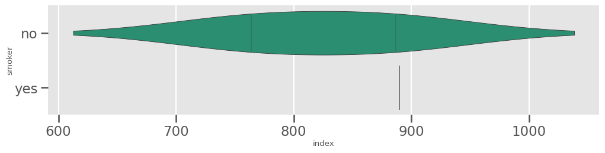

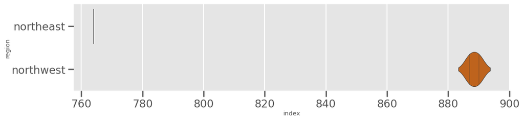

```python
# # Rearrange the columns in to numerical and categorical features
Xtest = Xtest[['age', 'bmi', 'children','sex', 'smoker','region']]
```

```python
# Retrieve the values of a specific row (index 764) from the testing features dataset and convert them to a list
Xtest.loc[764].tolist()
```

```
[45, 25.175, 2, 'female', 'no', 'northeast']
```

```python
# Randomly sample 100 rows from the testing features dataset
Xtest_sample = Xtest.sample(100)
```

```python
# Convert the sampled rows from the DataFrame to a list of tuples
Xtest_sample_rows = list(Xtest_sample.itertuples(index=False, name=None))
```

```python
# Access the first tuple in the list of sampled rows
Xtest_sample_rows[0]
```

```
(47, 29.37, 1, 'female', 'no', 'southeast')
```

## Inference

```python
# Create a Gradio client instance for the specified Gradio interface
client = Client("mayankchugh-learning/insurance-cost")
```

```
Loaded as API: https://mayankchugh-learning-insurance-cost.hf.space ✔
```

## Online/Real time

```python
# Submit a single data point prediction request to the Gradio interface
job = client.predict(
    age=33,
    bmi=32.90,
    children=1,
    sex="male",
    smoker="no",
    region="southhwest",
    api_name="/predict"
)
```

```python
# Print the result of the prediction job
print(job)
```

```
{'label': '7586.43', 'confidences': None}
```

```python
# Submit a single data point prediction request to the Gradio interface
job = client.predict(
    age=35,
    bmi=32,
    children=3,
    sex="female",
    smoker="yes",
    region="northwest",
    api_name="/predict"
)
```

```python
# Print the result of the prediction job
print(job)
```

```
{'label': '32406.18', 'confidences': None}
```

## Batch

```python
# Initialize an empty list to store batch predictions
batch_predictions = []
```

```python
# Iterate through the sampled rows and submit prediction requests to the Gradio interface
# Store the results in batch_predictions list
for row in tqdm(Xtest_sample_rows):
    try:
        # Submit a prediction request for the current row
        job = client.submit(
            age=row[0],
            bmi=row[1],
            children=row[2],
            sex=row[3],
            smoker=row[4],
            region=row[5],
            api_name="/predict"
        )

        # Wait for the job to complete and get the result
        prediction = job.result()['label']
        # Append the prediction result to batch_predictions
        batch_predictions.append(int(round(float(prediction))))

        # Sleep for 1 second before processing the next row
        time.sleep(1)

    except Exception as e:
        # Print any exceptions that occur during the prediction
        print(e)
```

```python
# Display the first 10 predictions from the batch_predictions list
batch_predictions[0:10]
```

```
[9814, 1873, 8662, 12897, 6581, 37098, 15240, 12861, 6378, 1120]
```

# Unit Testing

## Setup

```python
# Install the gradio_client package silently using pip
!pip install -q gradio_client
```

```python
# Import necessary libraries
from gradio_client import Client  # Import the Gradio client for interacting with Gradio interfaces
from sklearn.model_selection import train_test_split  # Import train_test_split for splitting datasets
from tqdm import tqdm  # Import tqdm for progress bars
from sklearn.metrics import mean_squared_error, r2_score
```

```python
# Create a Gradio client instance for the specified Gradio interface
client = Client("mayankchugh-learning/insurance-cost")
```

```
Loaded as API: https://mayankchugh-learning-insurance-cost.hf.space ✔
```

## Baseline Checks

Test Data

```python
import pandas as pd  # Import pandas for data manipulation
from sklearn.model_selection import train_test_split  # Import train_test_split for splitting datasets

# Read the dataset from the CSV file into a DataFrame
data_df = pd.read_csv("insurance.csv")

# Define the target variable and features
# Define the target variable
target = 'charges'

# Define the numeric features used for modeling
numeric_features = ['age', 'bmi', 'children']

# Define the categorical features used for modeling
categorical_features = ['sex', 'smoker','region']

# Display a message indicating the creation of data subsets
print("data subsets are being created")

# Create feature matrix (X) and target vector (y)
X = data_df.drop('charges', axis=1)
y = data_df['charges']


# Split the dataset into training and testing sets
Xtrain, Xtest, ytrain, ytest = train_test_split(
    X, y,
    test_size=0.2,
    random_state=42
)

# Rearrange the columns in to numerical and categorical features
Xtest = Xtest[['age', 'bmi', 'children', 'sex', 'smoker','region']]


# Randomly sample 100 rows from the testing features dataset
Xtest_sample = Xtest.sample(100)
ytest_sample = ytest.loc[Xtest_sample.index]

# Convert the sampled rows from the DataFrame to a list of tuples
Xtest_sample_rows = list(Xtest_sample.itertuples(index=False, name=None))
```

```
data subsets are being created
```

```python
Xtest_sample_rows
```

```
[(23, 36.67, 2, 'female', 'yes', 'northeast'),
 (50, 32.11, 2, 'male', 'no', 'northeast'),
 (40, 29.3, 4, 'female', 'no', 'southwest'),
 (53, 33.25, 0, 'female', 'no', 'northeast'),
 (18, 41.14, 0, 'male', 'no', 'southeast'),
 (39, 42.655, 0, 'male', 'no', 'northeast'),
 (23, 41.91, 0, 'male', 'no', 'southeast'),
 (60, 28.9, 0, 'male', 'no', 'southwest'),
 (18, 30.14, 0, 'male', 'no', 'southeast'),
 (23, 27.36, 1, 'male', 'no', 'northwest'),
 (41, 40.26, 0, 'male', 'no', 'southeast'),
 (22, 21.28, 3, 'female', 'no', 'northwest'),
 (47, 25.41, 1, 'male', 'yes', 'southeast'),
 (28, 33.0, 2, 'female', 'no', 'southeast'),
 (44, 31.35, 1, 'male', 'yes', 'northeast'),
 (47, 36.63, 1, 'female', 'yes', 'southeast'),
 (52, 30.875, 0, 'female', 'no', 'northeast'),
 (18, 35.2, 1, 'male', 'no', 'southeast'),
 (63, 37.7, 0, 'female', 'yes', 'southwest'),
 (33, 28.27, 1, 'female', 'no', 'southeast'),
 (51, 18.05, 0, 'female', 'no', 'northwest'),
 (49, 41.47, 4, 'female', 'no', 'southeast'),
 (32, 28.93, 1, 'male', 'yes', 'southeast'),
 (52, 18.335, 0, 'female', 'no', 'northwest'),
 (49, 29.83, 1, 'male', 'no', 'northeast'),
 (64, 22.99, 0, 'female', 'yes', 'southeast'),
 (29, 35.5, 2, 'male', 'yes', 'southwest'),
 (23, 24.51, 0, 'male', 'no', 'northeast'),
 (40, 41.42, 1, 'female', 'no', 'northwest'),
 (47, 45.32, 1, 'female', 'no', 'southeast'),
 (64, 25.6, 2, 'male', 'no', 'southwest'),
 (27, 24.75, 0, 'female', 'yes', 'southeast'),
 (41, 32.2, 2, 'male', 'no', 'southwest'),
 (29, 24.6, 2, 'female', 'no', 'southwest'),
 (54, 28.88, 2, 'female', 'no', 'northeast'),
 (44, 38.95, 0, 'female', 'yes', 'northwest'),
 (47, 26.125, 1, 'female', 'yes', 'northeast'),
 (29, 29.64, 1, 'male', 'no', 'northeast'),
 (60, 18.335, 0, 'female', 'no', 'northeast'),
 (55, 27.645, 0, 'male', 'no', 'northwest'),
```

[output cut: 45 more lines]

```
 (30, 23.655, 3, 'female', 'yes', 'northwest'),
 (35, 23.465, 2, 'female', 'no', 'northeast'),
 (62, 38.83, 0, 'male', 'no', 'southeast'),
 (22, 33.77, 0, 'male', 'no', 'southeast'),
 (22, 23.18, 0, 'female', 'no', 'northeast'),
 (36, 29.92, 0, 'female', 'no', 'southeast'),
 (20, 26.84, 1, 'female', 'yes', 'southeast'),
 (43, 32.6, 2, 'male', 'no', 'southwest'),
 (31, 25.935, 1, 'male', 'no', 'northwest'),
 (42, 40.37, 2, 'female', 'yes', 'southeast'),
 (26, 33.915, 1, 'male', 'no', 'northwest'),
 (45, 25.7, 3, 'female', 'no', 'southwest'),
 (50, 25.6, 0, 'female', 'no', 'southwest'),
 (57, 22.23, 0, 'female', 'no', 'northeast'),
 (26, 30.0, 1, 'male', 'no', 'southwest')]
```

Predictions on the test data

```python
# Initialize an empty list to store baseline test predictions
baseline_test_predictions = []

# Iterate through the sampled rows and submit prediction requests to the Gradio interface
for row in tqdm(Xtest_sample_rows):
    try:
        # Submit a prediction request for the current row
        job = client.submit(
            age=row[0],
            bmi=row[1],
            children=row[2],
            sex=row[3],
            smoker=row[4],
            region=row[5],
            api_name="/predict"
        )

        # Get the prediction result and append it to baseline_test_predictions
        prediction = job.result()['label']
        baseline_test_predictions.append(int(round(float(prediction))))
        # baseline_test_predictions.append(int(prediction))

    except Exception as e:
        # Print any exceptions that occur during prediction
        print(e)
```

Estimation of accuracy on the test sample. use RMSE and R-squared to measure the performance of the model

```python
print(f"RMSE: {mean_squared_error(ytest_sample, baseline_test_predictions, squared=False)}")
```

```
RMSE: 5522.009550000199
```

```python
print(f"R-squared: {r2_score(ytest_sample, baseline_test_predictions)}")
```

```
R-squared: 0.7801251804920715
```

If the Mean Absolute Error (MAE) or Root Mean Square Error (RMSE) is lower than the existing baseline (human or a previous model version), we move on to unit tests.